# Race, Culture, and Labour Supply Under Universal Basic Income

Evidence from the Manitoba Basic Annual Income Experiment (MINCOME)

Author

ECON 490 Capstone

Published

March 23, 2026

# 1 Introduction

With a cost-of-living crisis affecting much of the Western world, Canadians are struggling to afford basic necessities. One-time government transfers have provided short-term relief, but have not addressed underlying wealth inequality. In response, guaranteed income proposals have attracted renewed policy attention: Sen. Kim Pate’s Bill S-206, the *National Framework for a Guaranteed Livable Basic Income Act*, reflects this growing interest (Mendelson, 2019).

Universal Basic Income (UBI) is a social program that provides an unconditional living wage without a work requirement or means testing. Critics argue that such a cash transfer reduces labour supply, as workers are less incentivized to work if their basic needs are covered. Which is consistent with standard labour supply theory in which higher non-labour income shifts the income-leisure trade-off toward leisure (Paz-Báñez et al., 2020; Yi, 2017).

## 1.1 Literature Review

Kőmüves et al. (2022) studied UBI in the UK using the E3ME macroeconomic model, finding that a UBI funded via debt-free sovereign money raised employment and GDP while reducing labour supply, with no inflationary residual. In a developing-economy context, Santos & Van Doornik (2024) used a difference-in-differences strategy with Brazilian unemployment insurance data to simulate UBI effects, finding improved employment and reduced informality, with stronger effects on less-educated workers. Verho et al. (2022) examined the Finnish Basic Income Experiment, finding no employment effect in year one and a small positive effect in year two, with overall limited impact on labour supply.

For the MINCOME experiment specifically, Riddell & Riddell (2000) conducted post-hoc linear regression on the Manitoba data, finding the most substantial effect was a negative impact on hours worked for women in dual-income households, with an opposite effect for women in single-parent households. Hum & Simpson (1993) similarly documented small but significant decreases in working hours across the experiment.

## 1.2 Contributions

This paper takes an econometric approach to the MINCOME data, using fixed-effects, difference-in-differences, and triple-differences models to estimate the effect of guaranteed income payments on household labour supply. Crucially, it extends prior work in a dimension understudied in the existing literature. Specifically by examining whether the labour supply response differs between racialized and non-racialized households. Canada provides an instructive comparison: it spends proportionally less of its GDP on social protection than Finland (European Commission, 2025; OECD, 2023) but more than Brazil (Arnold & Bueno, 2021), situating the MINCOME results between a high-benefit Nordic context and a developing-economy context.

# 2 Data

## 2.1 Sources

Two datasets from the MINCOME experiment are used:

- **MINC3** (`MINC3.xlsx`): Cross-sectional baseline survey containing household demographics, pre-experiment income, ethnic background of male and female household heads, and asset information.
- **MINC4** (`MINC4.xlsx`): Longitudinal payment records spanning 11 survey periods, including monthly hours worked and wages for each household member, and the guaranteed income plan assigned.

## 2.2 Key Variable Definitions

| Variable | Description |
| --- | --- |
| `HHHRWRK` | Annual household hours worked (male + female head) |
| `HH_HOURS` | Monthly household hours (panel version of above) |
| `RACIALHH` | 1 if either household head belongs to a racialized ethnic group |
| `TREATED` | 1 if household was assigned to any treatment plan (i.e., not control) |
| `GBI_MON` | Monthly guaranteed basic income entitlement |
| `PAYMENT` | Actual benefit received, net of tax-back: $\max(0,\; G - \tau \cdot W)$ |
| `post` | 1 for periods after baseline (period > 0) |
| `period` | Survey wave (0 = baseline, 1–11 = experimental periods) |

Racialized households are defined as those where the male or female head identifies with any of the following ethnic groups: Philippine, Chinese, Native Indian (band), Native Indian (non-band), Other, African, West Indian, South American, Black, or Japanese.

## 2.3 Descriptive Statistics

Unique

Missing Pct.

Mean

SD

Min

Median

Max

Histogram

Family Size

12

25

3.3

2.0

1.0

3.0

12.0

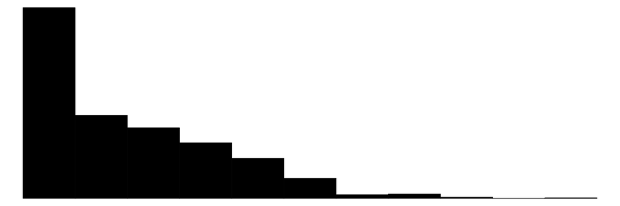

Total Family Income

695

27

7177.8

4053.3

0.0

6825.0

25911.0

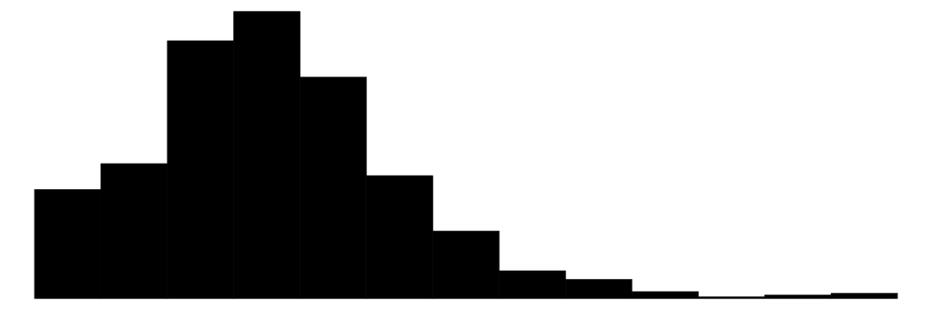

Annual HH Hours Worked

102

59

693.0

209.2

0.0

775.0

1399.0

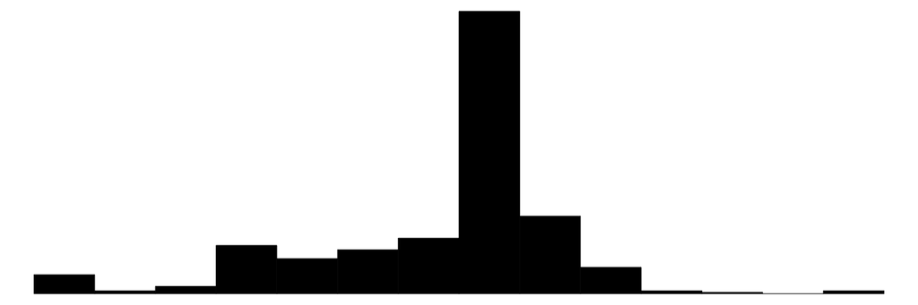

Racialized HH

2

0

0.1

0.2

0.0

0.0

1.0

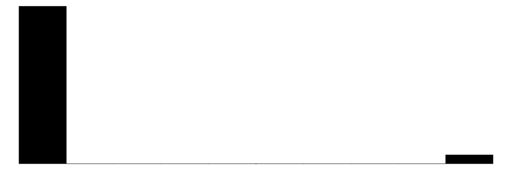

### 2.3.1 Sample Composition by Site

Summary statistics by MINCOME experimental site

| Site | N | Avg. Income ($) | Avg. Hours |
| --- | --- | --- | --- |
| Dauphin | 158 | 5576.7 | 672.5 |
| Rural | 75 | 6123.3 | 688.5 |
| Winnipeg | 519 | 7823.1 | 700.9 |
| NA | 250 | NaN | NaN |

Household count by site and racial classification

| Site | Racial Group | Count |
| --- | --- | --- |
| Dauphin | Non-racialized | 156 |
| Dauphin | Racialized | 2 |
| Rural | Non-racialized | 72 |
| Rural | Racialized | 3 |
| Winnipeg | Non-racialized | 471 |
| Winnipeg | Racialized | 48 |
| NA | Non-racialized | 250 |

# 3 Exploratory Data Analysis

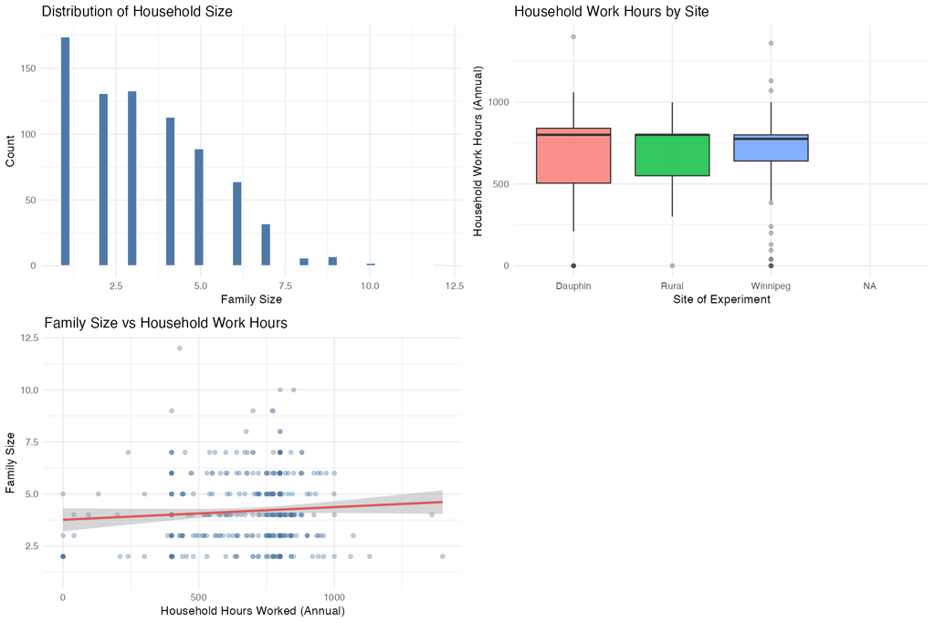

EDA overview: household size distribution (top left), annual work hours by experimental site (top right), and family size vs. work hours (bottom left).

# 4 Models

All models are estimated using the `fixest` package with standard errors clustered at the household level, unless otherwise noted.

## 4.1 Fixed Effects Model

The baseline specification controls for household-level unobservables and time-period shocks:

$$\text{HH\_HOURS}_{it} = \beta_1 \text{HH\_WAGE}_{it} + \beta_2 \text{PAYMENT}_{it} + \alpha_i + \gamma_t + \varepsilon_{it}$$

where $\alpha_i$ is a household fixed effect and $\gamma_t$ is a period fixed effect.

## 4.2 Difference-in-Differences Model

$$\text{HH\_HOURS}_{it} = \beta_1 (\text{TREATED}_i \times \text{post}_t) + \alpha_i + \gamma_t + \varepsilon_{it}$$

This identifies the average treatment effect on household work hours by comparing treated and control households before and after the experiment began.

## 4.3 Triple Differences (Racialized vs. Non-racialized)

To identify heterogeneous effects by racial identity, we add a third interaction:

$$\text{HH\_HOURS}_{it} = \beta_1 (\text{Treated} \times \text{Post})_{it}
+ \beta_2 (\text{Treated} \times \text{Post} \times \text{Racialized})_{it}
+ \alpha_i + \gamma_t + \varepsilon_{it}$$

The coefficient $\beta_2$ captures the **differential** labour supply response of racialized households relative to non-racialized households receiving the same treatment.

## 4.4 Results

Main regression results: effect of MINCOME on monthly household hours worked

|  | Fixed Effects | Diff-in-Diff | Triple Diff (DDD) |
| --- | --- | --- | --- |
| HH_WAGE | 0.496*** |  |  |
|  | (0.107) |  |  |
| PAYMENT | -0.616* |  |  |
|  | (0.245) |  |  |
| TREATED × post |  | -108.525* |  |
|  |  | (47.078) |  |
| treat_post |  |  | -108.033* |
|  |  |  | (47.398) |
| triple_diff |  |  | -4.915 |
|  |  |  | (72.412) |
| Num.Obs. | 4917 | 5168 | 5168 |
| R2 | 0.639 | 0.589 | 0.589 |
| R2 Adj. | 0.602 | 0.548 | 0.548 |

+ p < 0.1, * p < 0.05, ** p < 0.01, *** p < 0.001

# 5 Robustness Checks

To address potential heteroskedasticity in the error structure, we re-estimate all three models using heteroskedasticity-robust standard errors.

Robustness check: heteroskedasticity-robust standard errors

|  | FE (Robust) | DiD (Robust) | DDD (Robust) |
| --- | --- | --- | --- |
| HH_WAGE | 0.496*** |  |  |
|  | (0.094) |  |  |
| PAYMENT | -0.616** |  |  |
|  | (0.205) |  |  |
| TREATED × post |  | -108.525* | -108.033* |
|  |  | (48.838) | (49.179) |
| TREATED × post × RACIALHH |  |  | -4.915 |
|  |  |  | (73.879) |
| Num.Obs. | 4917 | 5168 | 5168 |
| R2 | 0.639 | 0.589 | 0.589 |
| R2 Adj. | 0.602 | 0.548 | 0.548 |

+ p < 0.1, * p < 0.05, ** p < 0.01, *** p < 0.001

The pattern of coefficients is consistent across both sets of standard errors, indicating that the main results are not sensitive to assumptions about error variance.

# 6 Event Study

To evaluate the parallel trends assumption underlying the DiD strategy, we estimate an event study specification that allows the treatment effect to vary freely across periods:

$$\text{HH\_HOURS}_{it} = \sum_{k \neq 0} \delta_k \cdot \mathbf{1}[t=k] \cdot \text{Treated}_i + \alpha_i + \gamma_t + \varepsilon_{it}$$

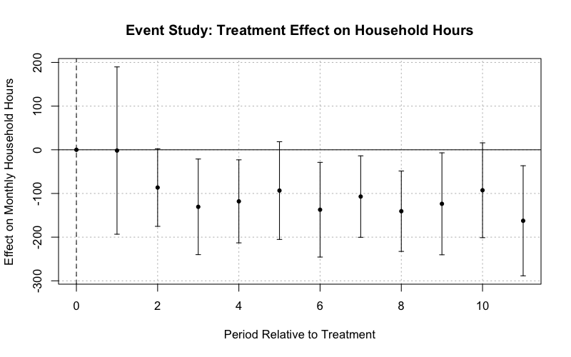

Event study estimates of the treatment effect on monthly household hours. Period 0 (baseline) is the reference. Vertical bars show 95% confidence intervals.

# 7 Conclusion

This analysis provides evidence on how guaranteed income transfers affect household labour supply in the MINCOME experiment, with particular attention to heterogeneity by racial identity. The fixed effects and difference-in- differences estimates capture the average response, while the triple-differences model isolates whether racialized households adjust their work hours differently in response to the same income guarantee.

These findings are consistent with Hum & Simpson (1993) and Riddell & Riddell (2000), who documented small reductions in hours worked in the same experiment, and with Verho et al. (2022) who found limited labour supply effects in Finland. The insignificance of the triple-difference term echoes Santos & Van Doornik (2024)’s finding that effects were stronger for disadvantaged subgroups in a developing-economy context, but suggests more homogeneous responses in the Canadian setting. Future work could extend this framework to examine effects by sex of household head, benefit level, or geographic site, and could incorporate longer follow-up data to assess persistence.

# 8 References

Arnold, J., & Bueno, D. (2021). *Social protection in Brazil: Addressing inequalities and investing in people*. OECD Economics Department. https://www.oecd.org/economy/surveys/brazil-2020-oecd-economic-survey.pdf

European Commission. (2025). *Finland: Social protection*. European Commission. https://ec.europa.eu/social/main.jsp?catId=1139&langId=en&intPageId=3639

Hum, D., & Simpson, W. (1993). Economic response to a guaranteed annual income: Experience from Canada and the United States. *Journal of Labor Economics*, *11*(1), S263–S296.

Kőmüves, Z., Thoung, C., & Zagdanski, J. (2022). *Macroeconomic implications of a basic income*. Cambridge Trust for New Thinking in Economics. https://neweconomicthinking.org.uk/wp-content/uploads/2022/12/CTNTE_Macroeconomics-basic-income_Finalpaper.pdf

Mendelson, M. (2019). *Lessons from Ontario’s basic income pilot*. Maytree. https://maytree.com/wp-content/uploads/Lessons-from-Ontarios-Basic-Income-Pilot.pdf

OECD. (2023). *Social expenditure database (SOCX)*. OECD. https://www.oecd.org/social/expenditure.htm

Paz-Báñez, M. A. de, Asensio-Coto, M. J., Sánchez-López, C., & Aceytuno, M.-T. (2020). Is there empirical evidence on how the implementation of a universal basic income (UBI) affects labour supply? A systematic review. *Sustainability*, *12*(22). https://doi.org/10.3390/su12229459

Riddell, W. C., & Riddell, R. (2000). Welfare switching and the negative income tax: Evidence from the Manitoba basic annual income experiment. *Canadian Public Policy*, *26*(4).

Santos, M. R., & Van Doornik, B. (2024). *Labor market effects of unemployment insurance and UBI in developing economies*. https://doi.org/10.2139/ssrn.4929252

Verho, J., Hämäläinen, K., & Kanninen, O. (2022). Removing welfare traps: Employment responses in the Finnish basic income experiment. *American Economic Journal: Economic Policy*, *14*(1), 501–522. https://doi.org/10.1257/pol.20200143

Yi, G. (2017). *The effects of basic income on labour supply*. Basic Income Earth Network. https://basicincome.org/wp-content/uploads/2015/01/Gunmin_Yi_The_Effects_of_Basic_Income_on_Labour_Supply.pdf

# 9 Appendix

## 9.1 Project Structure

```
ubi-analysis/
├── data/
│   ├── 01-raw/          # MINC3.xlsx, MINC4.xlsx (not tracked in git)
│   └── 02-clean/        # Generated by scripts
├── scripts/
│   ├── 01_load_data.R
│   ├── 02_clean_data.R
│   ├── 03_eda.R
│   └── 04_model.R
├── results/
│   ├── figures/
│   └── models/
├── reports/
│   └── ubi_analysis_report.qmd  ← this document
├── Makefile
└── renv.lock
```

Run the full pipeline with:

```bash
make all
```